# Mushroom edible and Poisonous Data

```python
# import libraries
import numpy as np
import pandas as pd
import seaborn as sns
import matplotlib.pyplot as plt
```

```python
import warnings
warnings.filterwarnings("ignore")
```

```python
#importing the dataset into Pandas Dataframe
df=pd.read_csv(r"C:\Users\PRAVEENA PRAKASH\mushrooms.csv")
```

```python
df.head()
```

|  | class | cap-shape | cap-surface | cap-color | bruises | odor | gill-attachment | gill-spacing | gill-size | gill-color | ... | stalk-surface-below-ring | stalk-color-above-ring | stalk-color-below-ring | veil-type | veil-color | ring-number | ring-type | spore-print-color | population | habitat |
| --- | --- | --- | --- | --- | --- | --- | --- | --- | --- | --- | --- | --- | --- | --- | --- | --- | --- | --- | --- | --- | --- |
| 0 | p | x | s | n | t | p | f | c | n | k | ... | s | w | w | p | w | o | p | k | s | u |
| 1 | e | x | s | y | t | a | f | c | b | k | ... | s | w | w | p | w | o | p | n | n | g |
| 2 | e | b | s | w | t | l | f | c | b | n | ... | s | w | w | p | w | o | p | n | n | m |
| 3 | p | x | y | w | t | p | f | c | n | n | ... | s | w | w | p | w | o | p | k | s | u |
| 4 | e | x | s | g | f | n | f | w | b | k | ... | s | w | w | p | w | o | e | n | a | g |

5 rows × 23 columns

```python
df.shape
```

```
(8124, 23)
```

```python
df.columns
```

```
Index(['class', 'cap-shape', 'cap-surface', 'cap-color', 'bruises', 'odor',
       'gill-attachment', 'gill-spacing', 'gill-size', 'gill-color',
       'stalk-shape', 'stalk-root', 'stalk-surface-above-ring',
       'stalk-surface-below-ring', 'stalk-color-above-ring',
       'stalk-color-below-ring', 'veil-type', 'veil-color', 'ring-number',
       'ring-type', 'spore-print-color', 'population', 'habitat'],
      dtype='object')
```

## Data Schema

Column 1: class

```
* Description: Edibility classification
* Values: e = edible, p = poisonous
```

Column 2: cap-shape

```
* Description: Shape of the mushroom cap
* Values: b = bell, c = conical, x = convex, f = flat, k = knobbed, s = sunken
```

Column 3: cap-surface

```
* Description: Surface texture of the cap
* Values: f = fibrous, g = grooves, y = scaly, s = smooth
```

Column 4: cap-color

```
* Description: Color of the mushroom cap
* Values: n = brown, b = buff, c = cinnamon, g = gray, r = green, p = pink, u = purple, e = red, w = white, y = yellow
```

Column 5: bruises

```
* Description: Whether the mushroom bruises when touched
* Values: t = bruises, f = no bruises
```

Column 6: odor

```
* Description: Smell of the mushroom
* Values: a = almond, l = anise, c = creosote, y = fishy, f = foul, m = musty, n = none, p = pungent, s = spicy
```

Column 7: gill-attachment

```
* Description: How gills are attached to the stalk
* Values: a = attached, d = descending, f = free, n = notched
```

Column 8: gill-spacing

```
* Description: Spacing between gills
* Values: c = close, w = crowded, d = distant
```

Column 9: gill-size

```
* Description: Width of the gills
* Values: b = broad, n = narrow
```

Column 10: gill-color

```
* Description: Color of the gills
* Values: k = black, n = brown, b = buff, h = chocolate, g = gray, r = green, o = orange, p = pink, u = purple, e = red, w = white, y = yellow
```

Column 11: stalk-shape

```
* Description: Shape of the stalk
* Values: e = enlarging, t = tapering
```

Column 12: stalk-root

```
* Description: Root structure of the stalk
* Values: b = bulbous, c = club, u = cup, e = equal, z = rhizomorphs, r = rooted, ? = missing
```

Column 13: stalk-surface-above-ring

```
* Description: Surface texture of stalk above the ring
* Values: f = fibrous, y = scaly, k = silky, s = smooth
```

Column 14: stalk-surface-below-ring

```
* Description: Surface texture of stalk below the ring
* Values: f = fibrous, y = scaly, k = silky, s = smooth
```

Column 15: stalk-color-above-ring

```
* Description: Color of stalk above the ring
* Values: n = brown, b = buff, c = cinnamon, g = gray, o = orange, p = pink, e = red, w = white, y = yellow
```

Column 16: stalk-color-below-ring

```
* Description: Color of stalk below the ring
* Values: n = brown, b = buff, c = cinnamon, g = gray, o = orange, p = pink, e = red, w = white, y = yellow
```

Column 17: veil-type

```
* Description: Type of veil
* Values: p = partial, u = universal
```

Column 18: veil-color

```
* Description: Color of the veil
* Values: n = brown, o = orange, w = white, y = yellow
```

Column 19: ring-number

```
* Description: Number of rings on the stalk
* Values: n = none, o = one, t = two
```

Column 20: ring-type

```
* Description: Type of ring
* Values: c = cobwebby, e = evanescent, f = flaring, l = large, n = none, p = pendant, s = sheathing, z = zone
```

Column 21: spore-print-color

```
* Description: Color of spore print
* Values: k = black, n = brown, b = buff, h = chocolate, r = green, o = orange, u = purple, w = white, y = yellow
```

Column 22: population

```
* Description: Population density where found
* Values: a = abundant, c = clustered, n = numerous, s = scattered, v = several, y = solitary
```

Column 23: habitat

```
* Description: Natural habitat where mushroom grows
* Values: g = grasses, l = leaves, m = meadows, p = paths, u = urban, w = waste, d = woods
```

Dataset Summary:

```
* Total Records: 8,124 mushrooms
* Total Features: 23 columns
* Data Type: All categorical features (encoded as single characters)
* Target Variable: 'class' (edible vs poisonous)
```

```python
df.describe()
```

|  | class | cap-shape | cap-surface | cap-color | bruises | odor | gill-attachment | gill-spacing | gill-size | gill-color | ... | stalk-surface-below-ring | stalk-color-above-ring | stalk-color-below-ring | veil-type | veil-color | ring-number | ring-type | spore-print-color | population | habitat |
| --- | --- | --- | --- | --- | --- | --- | --- | --- | --- | --- | --- | --- | --- | --- | --- | --- | --- | --- | --- | --- | --- |
| count | 8124 | 8124 | 8124 | 8124 | 8124 | 8124 | 8124 | 8124 | 8124 | 8124 | ... | 8124 | 8124 | 8124 | 8124 | 8124 | 8124 | 8124 | 8124 | 8124 | 8124 |
| unique | 2 | 6 | 4 | 10 | 2 | 9 | 2 | 2 | 2 | 12 | ... | 4 | 9 | 9 | 1 | 4 | 3 | 5 | 9 | 6 | 7 |
| top | e | x | y | n | f | n | f | c | b | b | ... | s | w | w | p | w | o | p | w | v | d |
| freq | 4208 | 3656 | 3244 | 2284 | 4748 | 3528 | 7914 | 6812 | 5612 | 1728 | ... | 4936 | 4464 | 4384 | 8124 | 7924 | 7488 | 3968 | 2388 | 4040 | 3148 |

4 rows × 23 columns

## Data Cleaning

```python
# Check about missing values to decide whether need to make any data cleaning or not
df.isnull().sum()
```

```
class                       0
cap-shape                   0
cap-surface                 0
cap-color                   0
bruises                     0
odor                        0
gill-attachment             0
gill-spacing                0
gill-size                   0
gill-color                  0
stalk-shape                 0
stalk-root                  0
stalk-surface-above-ring    0
stalk-surface-below-ring    0
stalk-color-above-ring      0
stalk-color-below-ring      0
veil-type                   0
veil-color                  0
ring-number                 0
ring-type                   0
spore-print-color           0
population                  0
habitat                     0
dtype: int64
```

There is none of null values present in the dataset.

```python
df.info()
```

```
<class 'pandas.core.frame.DataFrame'>
RangeIndex: 8124 entries, 0 to 8123
Data columns (total 23 columns):
 #   Column                    Non-Null Count  Dtype
---  ------                    --------------  -----
 0   class                     8124 non-null   object
 1   cap-shape                 8124 non-null   object
 2   cap-surface               8124 non-null   object
 3   cap-color                 8124 non-null   object
 4   bruises                   8124 non-null   object
 5   odor                      8124 non-null   object
 6   gill-attachment           8124 non-null   object
 7   gill-spacing              8124 non-null   object
 8   gill-size                 8124 non-null   object
 9   gill-color                8124 non-null   object
 10  stalk-shape               8124 non-null   object
 11  stalk-root                8124 non-null   object
 12  stalk-surface-above-ring  8124 non-null   object
 13  stalk-surface-below-ring  8124 non-null   object
 14  stalk-color-above-ring    8124 non-null   object
 15  stalk-color-below-ring    8124 non-null   object
 16  veil-type                 8124 non-null   object
 17  veil-color                8124 non-null   object
 18  ring-number               8124 non-null   object
 19  ring-type                 8124 non-null   object
 20  spore-print-color         8124 non-null   object
 21  population                8124 non-null   object
 22  habitat                   8124 non-null   object
dtypes: object(23)
memory usage: 1.4+ MB
```

```python
df['stalk-root'].unique()
```

```
array(['e', 'c', 'b', 'r', '?'], dtype=object)
```

```python
# replace the value '?' with 'u' means unknown
df['stalk-root'] = df['stalk-root'].replace('?', 'u')
df['stalk-root'].unique()
```

```
array(['e', 'c', 'b', 'r', 'u'], dtype=object)
```

```python
df['veil-type'].unique()
```

```
array(['p'], dtype=object)
```

```python
# Here, veil-type has one one unique value['p']. So we can drop the column
df = df.drop('veil-type', axis=1)
df.head()
```

|  | class | cap-shape | cap-surface | cap-color | bruises | odor | gill-attachment | gill-spacing | gill-size | gill-color | ... | stalk-surface-above-ring | stalk-surface-below-ring | stalk-color-above-ring | stalk-color-below-ring | veil-color | ring-number | ring-type | spore-print-color | population | habitat |
| --- | --- | --- | --- | --- | --- | --- | --- | --- | --- | --- | --- | --- | --- | --- | --- | --- | --- | --- | --- | --- | --- |
| 0 | p | x | s | n | t | p | f | c | n | k | ... | s | s | w | w | w | o | p | k | s | u |
| 1 | e | x | s | y | t | a | f | c | b | k | ... | s | s | w | w | w | o | p | n | n | g |
| 2 | e | b | s | w | t | l | f | c | b | n | ... | s | s | w | w | w | o | p | n | n | m |
| 3 | p | x | y | w | t | p | f | c | n | n | ... | s | s | w | w | w | o | p | k | s | u |
| 4 | e | x | s | g | f | n | f | w | b | k | ... | s | s | w | w | w | o | e | n | a | g |

5 rows × 22 columns

```python
# finding number of unique categories
for column in df.columns:
    num_unique = df[column].nunique()
    print(f"'{column}' has {num_unique} unique categories.")
```

```
'class' has 2 unique categories.
'cap-shape' has 6 unique categories.
'cap-surface' has 4 unique categories.
'cap-color' has 10 unique categories.
'bruises' has 2 unique categories.
'odor' has 9 unique categories.
'gill-attachment' has 2 unique categories.
'gill-spacing' has 2 unique categories.
'gill-size' has 2 unique categories.
'gill-color' has 12 unique categories.
'stalk-shape' has 2 unique categories.
'stalk-root' has 5 unique categories.
'stalk-surface-above-ring' has 4 unique categories.
'stalk-surface-below-ring' has 4 unique categories.
'stalk-color-above-ring' has 9 unique categories.
'stalk-color-below-ring' has 9 unique categories.
'veil-color' has 4 unique categories.
'ring-number' has 3 unique categories.
'ring-type' has 5 unique categories.
'spore-print-color' has 9 unique categories.
'population' has 6 unique categories.
'habitat' has 7 unique categories.
```

```python
# Print top 10 unique value counts for each categorical column
for column in df.columns:
    print(f"\nTop value counts in '{column}':\n{df[column].value_counts().head(10)}")
```

```
Top value counts in 'class':
class
e    4208
p    3916
Name: count, dtype: int64

Top value counts in 'cap-shape':
cap-shape
x    3656
f    3152
k     828
b     452
s      32
c       4
Name: count, dtype: int64

Top value counts in 'cap-surface':
cap-surface
y    3244
s    2556
f    2320
g       4
Name: count, dtype: int64

Top value counts in 'cap-color':
cap-color
n    2284
g    1840
e    1500
y    1072
w    1040
b     168
p     144
c      44
u      16
r      16
Name: count, dtype: int64

Top value counts in 'bruises':
bruises
```

[output cut: 148 more lines]

```
n     400
a     384
c     340
Name: count, dtype: int64

Top value counts in 'habitat':
habitat
d    3148
g    2148
p    1144
l     832
u     368
m     292
w     192
Name: count, dtype: int64
```

## Data Visualization

### Distribution of Categorical Features

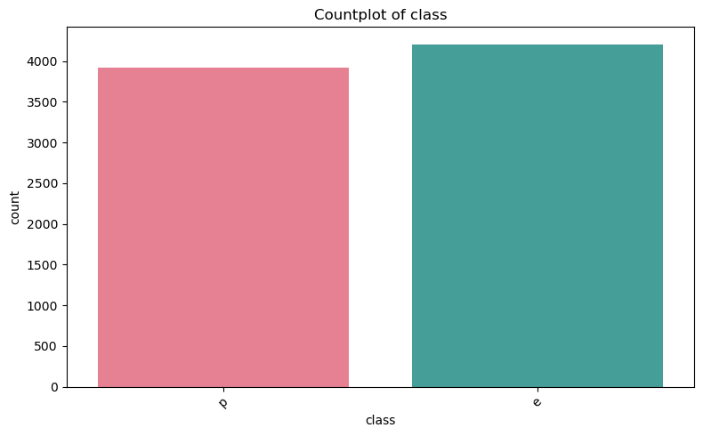

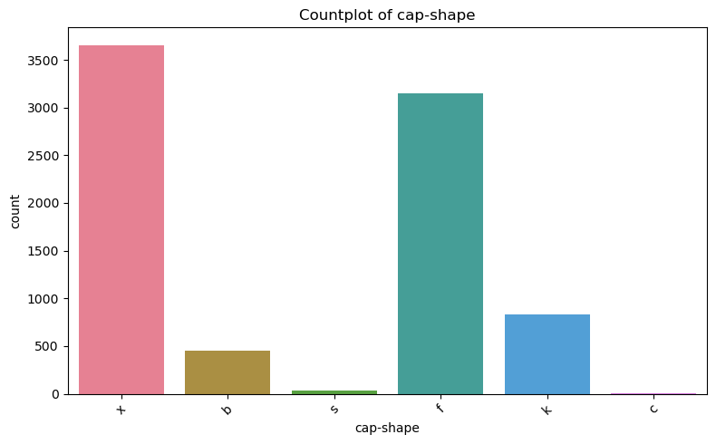

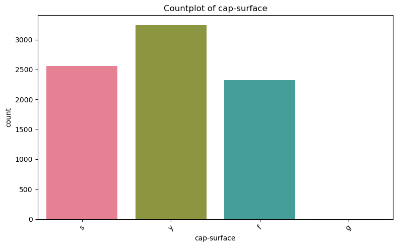

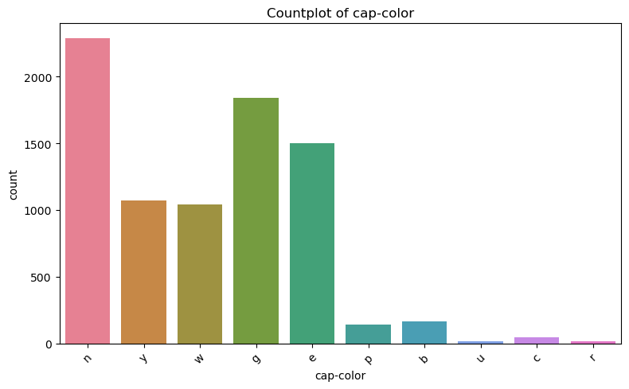

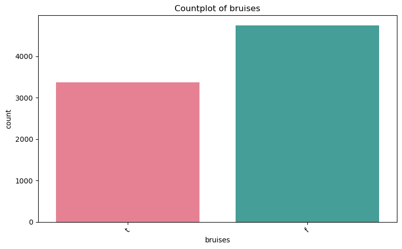

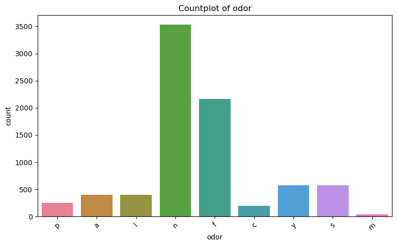

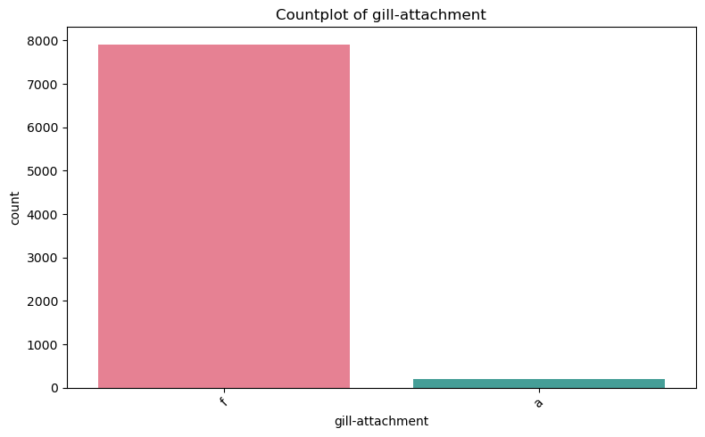

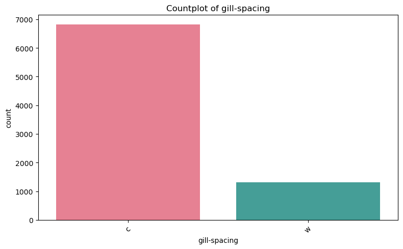

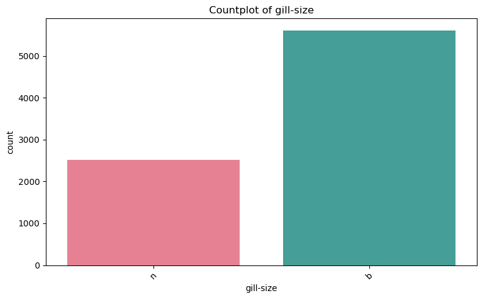

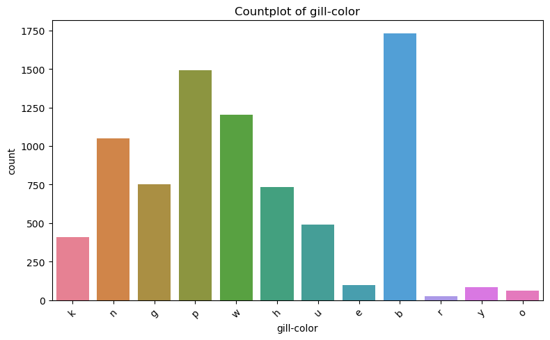

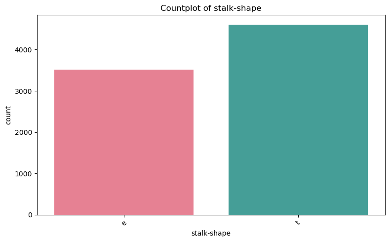

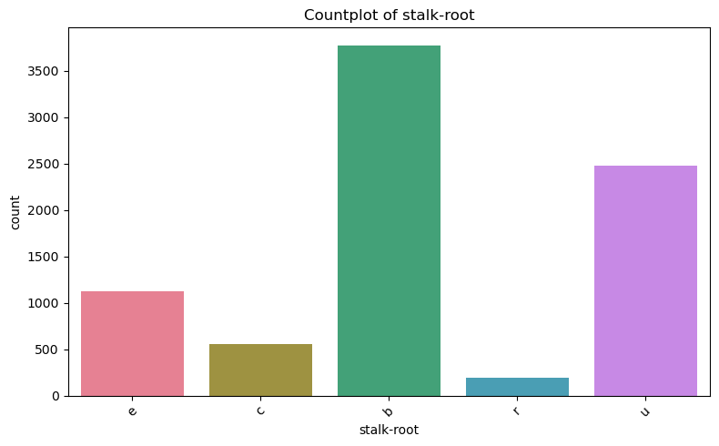

[10 more figures not shown]

```python
# Modify your plotting code to ensure each category gets a unique color
for column in df.columns:
    plt.figure(figsize=(8, 5))
    n_categories = df[column].nunique()
    colors = sns.color_palette("husl", n_categories)  # Generate as many colors as categories
    sns.countplot(data=df, x=column, palette=colors)
    plt.title(f'Countplot of {column}')
    plt.xticks(rotation=45)  # Rotate labels if needed
    plt.tight_layout()
    plt.show()
```

Countplot of 'class'

```
* The dataset shows a moderate class imbalance between edible (e) and poisonous (p) mushrooms
* Edible mushrooms (e): 4,208 samples (51.8% of the dataset)
* Poisonous mushrooms (p): 3,916 samples (48.2% of the dataset)
```

Countplot of 'cap-shape'

```
* The 'x' (convex) cap shape is by far the most common, appearing in approximately 3,656 mushrooms (about 45% of the dataset). This suggests that convex caps are the predominant shape in this mushroom          collection.
* The dataset contains 6 different cap-shape categories, providing good diversity for analysis, though the distribution is heavily skewed.
* Some cap shapes appear to be quite rare in the dataset (the smaller bars), which might represent more specialized or uncommon mushroom varieties.
```

Countplot of 'cap-surface'

[output not shown]

Countplot of 'cap-color'

```
* Several cap colors appear to be quite rare in the dataset, with some categories having very low frequencies. This suggests certain cap colors are uncommon in nature or in the specific mushroom species        included in this dataset.
```

Countplot of 'bruises'

```
* Approximately 58% of mushrooms in the dataset do not exhibit bruising when damaged, while 42% do show bruising. This suggests that bruising is a distinctive but not universal characteristic among             mushrooms.
```

Countplot of 'odor'

```
* 'n' (none) is the most frequent odor type with approximately 3,528 mushrooms, representing about 43% of the dataset
* 'f' (foul) appears to be the second most common with a significant count
* These two categories together account for the majority of mushrooms in the dataset
* Several odor categories have very low frequencies (appearing as small bars)
* This suggests that most mushrooms either have no distinctive odor or a foul smell
* Other specific odors like spicy, fishy, or sweet are relatively uncommon
```

Countplot of 'gill-attachment'

```
* The gill-attachment feature shows a stark imbalance between categories, with one category ('f' - likely "free") dominating at 7,914 occurrences out of 8,124 total samples (97.4%).
* The second category ('a' - likely "attached") represents only 210 samples (2.6% of the dataset), making it a minority class that could be important for mushroom classification.
```

Countplot of gill-spacing

```
* The dataset shows a significant imbalance in gill-spacing categories
* One category (likely 'c' for close) dominates with approximately 6,812 samples (about 84% of the data)
* The other category (likely 'w' for crowded) has only about 1,312 samples (about 16% of the data)
```

Countplot of gill-size

```
* The gill-size feature has only two categories - 'b' (broad) and 'n' (narrow), making it a binary categorical variable.
* Broad gills ('b'): Approximately 5,612 mushrooms (~69% of the dataset)
* Narrow gills ('n'): Approximately 2,512 mushrooms (~31% of the dataset)
```

Countplot of gill-color

[output not shown]

Countplot of stalk-shape

[output not shown]

Countplot of 'stalk-root'

[output not shown]

Countplot of 'stalk-surface-above-ring'

[output not shown]

Countplot of 'stalk-surface-below-ring'

```
* Similar to above-ring, smooth ('s') stalk surface below ring dominates with approximately 4,936 mushrooms (about 61%)
* Silky ('k') surface is again the second most frequent with around 2,304 samples (about 28%)
* Scaly ('y') and fibrous ('f') surfaces are much less common
* The pattern closely mirrors the above-ring distribution, suggesting consistency in stalk surface characteristics
```

Countplot of 'stalk-color-above-ring'

```
* White ('w') is the most prevalent stalk color above ring with approximately 4,464 mushrooms (about 55% of the dataset)
* Pink ('p') is the second most common with around 1,872 samples (about 23%)
* Gray ('g') and buff ('b') colors have moderate representation
* Several colors like orange ('o'), red ('r'), and yellow ('y') are quite rare
* The distribution shows a clear preference for lighter colors in stalk coloration
```

Countplot of 'stalk-color-below-ring'

```
* White ('w') again dominates with approximately 4,384 mushrooms (about 54% of the dataset)
* Pink ('p') is consistently the second most common with around 1,872 samples
* The distribution pattern is very similar to stalk-color-above-ring, indicating consistent coloration throughout the stalk
* This consistency between above and below ring colors suggests these features may be highly correlated
```

[output not shown]

Countplot of 'veil-color'

```
* White ('w') veil color is extremely dominant with approximately 7,924 mushrooms (about 97.5% of the dataset)
* Orange ('o') and yellow ('y') veil colors are present but extremely rare with less than 100 samples each
* Brown ('n') veil color has minimal representation
* This feature is highly imbalanced and may not provide significant discriminatory power
```

Countplot of 'ring-number'

```
* One ring ('o') is by far the most common with approximately 7,488 mushrooms (about 92% of the dataset)
* Two rings ('t') are much less common with around 600 samples (about 7.4%)
* None ('n') represents the smallest category with minimal samples
* This feature shows that most mushrooms in the dataset have exactly one ring
```

Countplot of 'ring-type'

```
* Pendant ('p') ring type is the most common with approximately 3,968 mushrooms (about 49%)
* Evanescent ('e') is the second most frequent with around 2,776 samples (about 34%)
* Large ('l') ring type has moderate representation with about 1,296 samples (about 16%)
* Flaring ('f') and none ('n') are quite rare categories
* This feature shows good diversity across different ring types
```

Countplot of 'spore-print-color'

```
* White ('w') spore print color dominates with approximately 2,388 mushrooms (about 29%)
* Brown ('n') is the second most common with around 1,968 samples (about 24%)
* Black ('k') represents about 1,872 samples (about 23%)
* Chocolate ('h') and buff ('b') have moderate representation
* Several colors like orange ('o'), yellow ('y'), and green ('r') are quite rare
* This feature shows relatively good distribution across multiple categories
```

Countplot of 'population'

[output not shown]

Countplot of 'habitat'

[output not shown]

### Summary of Categorical Data

```python
# For categorical data, create a contingency table
from scipy.stats import chi2_contingency

# Create a simple summary
print("Dataset Summary:")
print(df.describe(include='all'))
```

```
Dataset Summary:
       class cap-shape cap-surface cap-color bruises  odor gill-attachment  \
count   8124      8124        8124      8124    8124  8124            8124
unique     2         6           4        10       2     9               2
top        e         x           y         n       f     n               f
freq    4208      3656        3244      2284    4748  3528            7914

       gill-spacing gill-size gill-color  ... stalk-surface-above-ring  \
count          8124      8124       8124  ...                     8124
unique            2         2         12  ...                        4
top               c         b          b  ...                        s
freq           6812      5612       1728  ...                     5176

       stalk-surface-below-ring stalk-color-above-ring stalk-color-below-ring  \
count                      8124                   8124                   8124
unique                        4                      9                      9
top                           s                      w                      w
freq                       4936                   4464                   4384

       veil-color ring-number ring-type spore-print-color population habitat
count        8124        8124      8124              8124       8124    8124
unique          4           3         5                 9          6       7
top             w           o         p                 w          v       d
freq         7924        7488      3968              2388       4040    3148

[4 rows x 22 columns]
```

### Exploring Correlations between Categorical Features

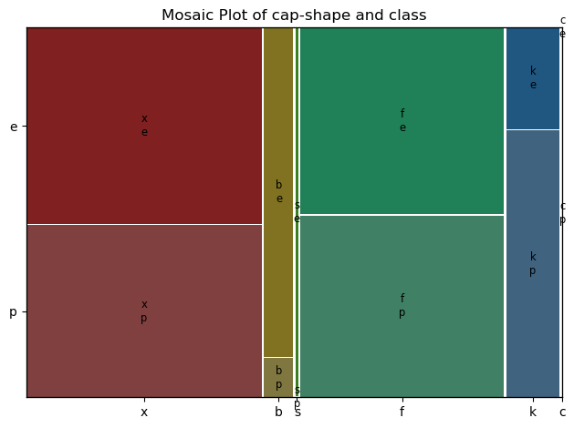

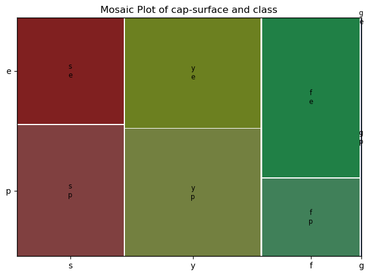

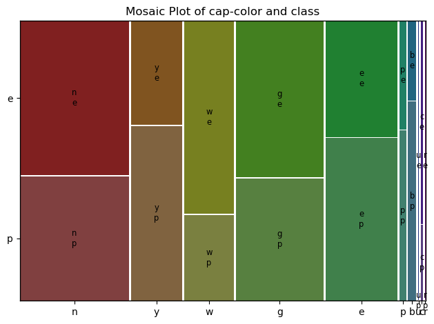

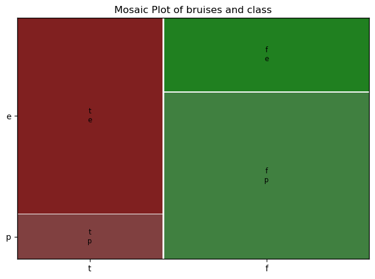

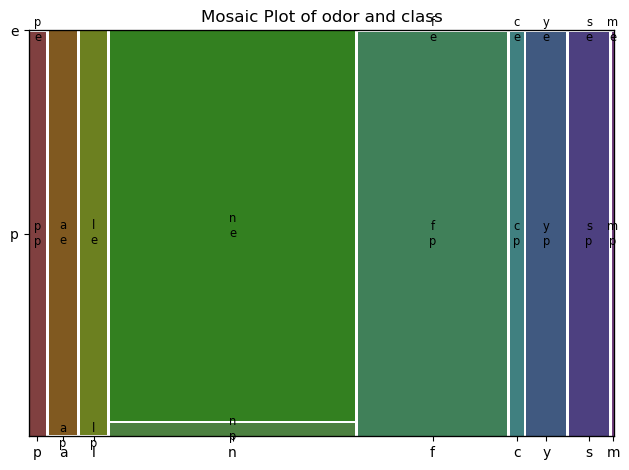

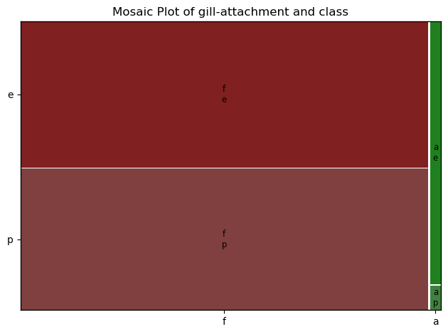

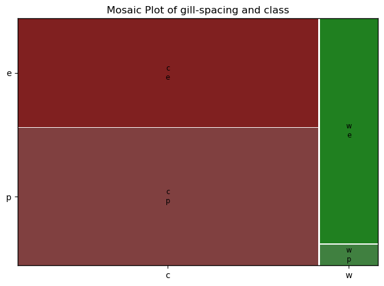

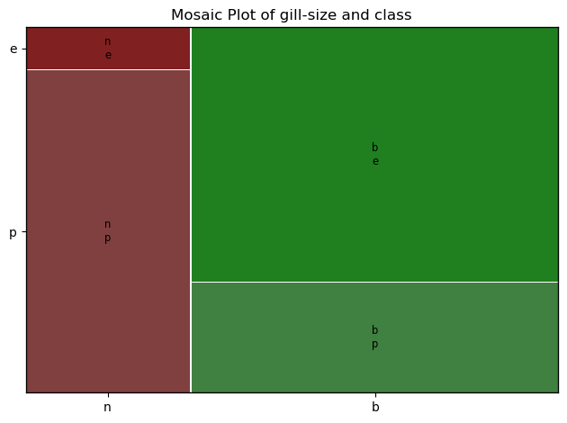

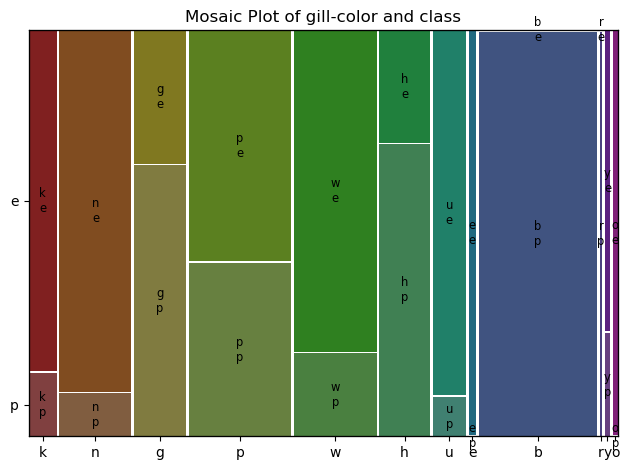

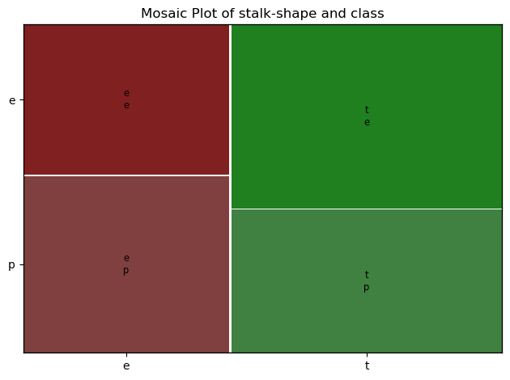

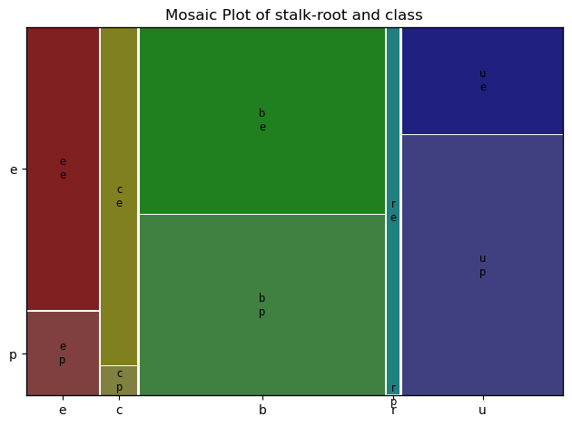

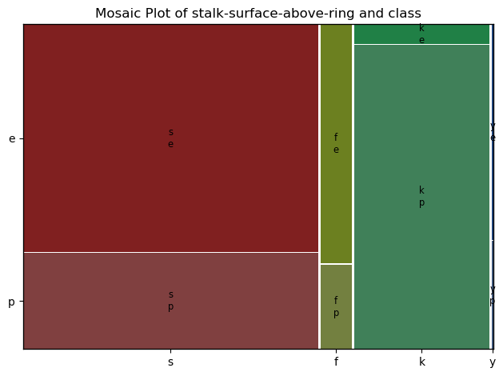

[9 more figures not shown]

```python
# Import the required libraries
from statsmodels.graphics.mosaicplot import mosaic
import matplotlib.pyplot as plt

# Plot mosaic plots for each categorical column (excluding 'class' to avoid self-comparison)
for column in df.columns:
    if column != 'class':  # Skip the target variable to avoid plotting it against itself
        plt.figure(figsize=(8, 6))
        mosaic(df, [column, 'class'])
        plt.title(f'Mosaic Plot of {column} and class')
        plt.tight_layout()
        plt.show()
```

Key Insights from Mushroom Dataset Categorical Analysis

1. Target Variable (Class) Distribution
   - Moderate class balance: 51.8% edible vs 48.2% poisonous mushrooms
   - This near-balanced distribution is favorable for machine learning model training
   - Total dataset size: 8,124 mushroom samples
2. Physical Characteristics Patterns

Cap Features:

[output not shown]

Gill Characteristics:

[output not shown]

3. Sensory and Physical Response Features

Odor Profile:

```
* Critical finding: 43% have no odor, while foul odor is the second most common
* This binary-like distribution (none vs foul) suggests odor could be a strong predictor of edibility
* Rare odors (spicy, fishy, sweet) represent specialized characteristics
```

Bruising Response:

```
* 58% no bruising vs 42% bruising - relatively balanced feature
* Bruising could be a reliable identification characteristic
```

### Distribution of Classes

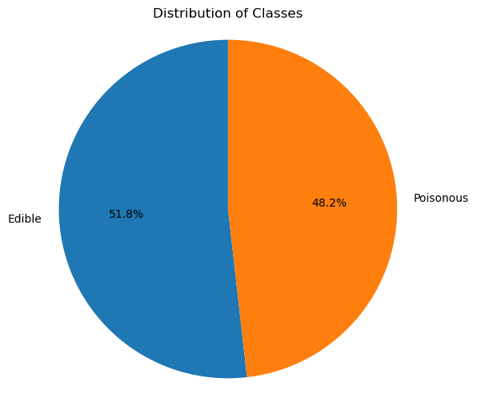

```python
# Calculate counts for the pie chart to find the percentage of edible vs poisonous
class_counts = df['class'].value_counts().sort_index()
labels = ["Edible", "Poisonous"]

plt.figure(figsize=(6, 6))
plt.pie(class_counts, labels=labels, autopct='%1.1f%%', startangle=90)
plt.title('Distribution of Classes')
plt.axis('equal')  # Equal aspect ratio ensures that pie is drawn as a circle.
plt.show()
```

The dataset demonstrates a well-balanced class distribution with approximately 51.8% edible mushrooms and 48.2% poisonous mushrooms.

### CORRELATION HEATMAP

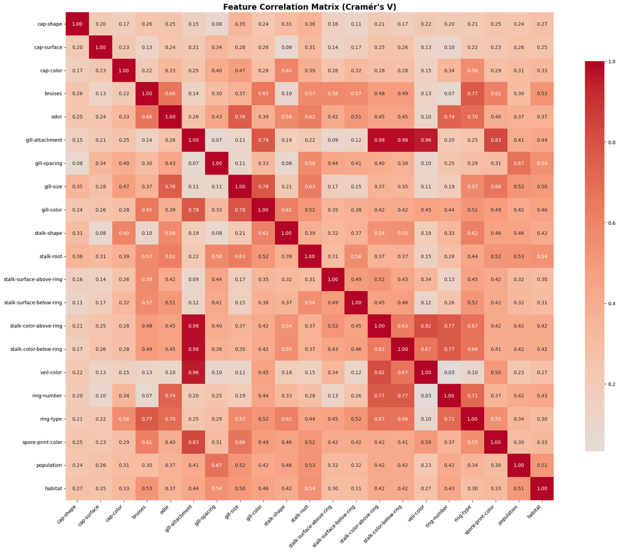

```python
# plot Feature Correlation Matrix
def cramers_v(x, y):
    confusion_matrix = pd.crosstab(x, y)
    chi2 = chi2_contingency(confusion_matrix)[0]
    n = confusion_matrix.sum().sum()
    return np.sqrt(chi2 / (n * (min(confusion_matrix.shape) - 1)))

# Calculate correlations
features = df.columns.drop('class')
correlation_matrix = pd.DataFrame(index=features, columns=features)

for i, feature1 in enumerate(features):
    for j, feature2 in enumerate(features):
        if i <= j:
            correlation_matrix.loc[feature1, feature2] = cramers_v(df[feature1], df[feature2])
            correlation_matrix.loc[feature2, feature1] = correlation_matrix.loc[feature1, feature2]

correlation_matrix = correlation_matrix.astype(float)

plt.figure(figsize=(20, 16))
sns.heatmap(correlation_matrix, annot=True, cmap='coolwarm', center=0,
            fmt='.2f', square=True, cbar_kws={'shrink': 0.8})
plt.title('Feature Correlation Matrix (Cramér\'s V)', fontsize=16, fontweight='bold')
plt.xticks(rotation=45, ha='right')
plt.yticks(rotation=0)
plt.tight_layout()
plt.show()
```

[output not shown]

### FEATURE IMPORTANCE

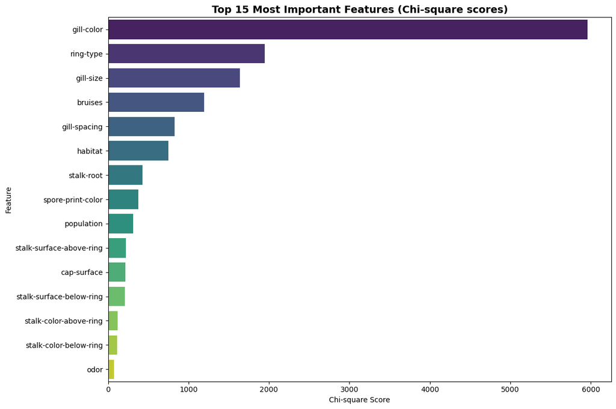

```python
from sklearn.feature_selection import chi2
from sklearn.preprocessing import LabelEncoder

# Encode all categorical variables
df_encoded = df.copy()
encoders = {}
for col in df_encoded.columns:
    le = LabelEncoder()
    df_encoded[col] = le.fit_transform(df_encoded[col])
    encoders[col] = le

X = df_encoded.drop('class', axis=1)
y = df_encoded['class']

chi2_scores, p_values = chi2(X, y)
feature_importance = pd.DataFrame({
    'Feature': X.columns,
    'Chi2_Score': chi2_scores,
    'P_Value': p_values
}).sort_values('Chi2_Score', ascending=False)

plt.figure(figsize=(12, 8))
sns.barplot(data=feature_importance.head(15), x='Chi2_Score', y='Feature', palette='viridis')
plt.title('Top 15 Most Important Features (Chi-square scores)', fontsize=14, fontweight='bold')
plt.xlabel('Chi-square Score')
plt.tight_layout()
plt.show()
```

[output not shown]

### TOP FEATURES vs TARGET ANALYSIS

[figure not shown]

```python
top_features = feature_importance.head(8)['Feature'].tolist()

fig, axes = plt.subplots(2, 4, figsize=(20, 12))
axes = axes.ravel()

for i, feature in enumerate(top_features):
    ct = pd.crosstab(df[feature], df['class'], normalize='index') * 100
    ct.plot(kind='bar', ax=axes[i], color=['lightcoral', 'lightgreen'],
            title=f'{feature.replace("-", " ").title()}')
    axes[i].set_xlabel('')
    axes[i].set_ylabel('Percentage')
    axes[i].legend(['Poisonous', 'Edible'])
    axes[i].tick_params(axis='x', rotation=45)

plt.suptitle('Distribution of Top 8 Features by Mushroom Class', fontsize=16, fontweight='bold')
plt.tight_layout()
plt.show()
```

[output not shown]

### INSIGHTS SUMMARY

```python
# First, let's check what columns we have in feature_importance
print("Columns in feature_importance DataFrame:")
print(feature_importance.columns.tolist())
print("\nFirst few rows:")
print(feature_importance.head())
```

```
Columns in feature_importance DataFrame:
['Feature', 'Chi2_Score', 'P_Value']

First few rows:
         Feature   Chi2_Score        P_Value
8     gill-color  5957.764469   0.000000e+00
17     ring-type  1950.610146   0.000000e+00
7      gill-size  1636.606833   0.000000e+00
3        bruises  1194.277352  1.069037e-261
6   gill-spacing   826.795274  8.061293e-182
```

```python
print(f"\n📊 DATASET OVERVIEW:")
print(f"• Total samples: {len(df):,}")
print(f"• Features: {len(df.columns)-1}")
print(f"• Target classes: {df['class'].nunique()} (Edible: {class_counts['e']}, Poisonous: {class_counts['p']})")
print(f"• Dataset balance: {(min(class_counts)/max(class_counts)*100):.1f}% balanced")

print(f"\n🔍 TOP PREDICTIVE FEATURES:")
# Check if feature_importance has the expected structure
if 'Feature' in feature_importance.columns and 'Importance' in feature_importance.columns:
    for i, (_, row) in enumerate(feature_importance.head(5).iterrows(), 1):
        print(f"{i}. {row['Feature'].replace('-', ' ').title()}: {row['Importance']:.3f}")
else:
    # Alternative approach if columns are different
    print("Feature importance data structure:")
    for i in range(min(5, len(feature_importance))):
        print(f"{i+1}. {feature_importance.iloc[i]}")
```

[output not shown]

### Key Insights

Dataset Overview:

```
* Sample Size: 8,124 mushroom samples
* Features: 21 characteristics analyzed
* Target Balance: 93.1% balanced (4,208 edible vs 3,916 poisonous)
* Analysis Method: Chi-square statistical test for feature importance
```

Top 5 Most Predictive Features:

```
1. Gill Color (Chi² = 5,957.76)

    * Most discriminating feature for mushroom classification
	* Extremely high statistical significance (p-value ≈ 0)
```

2. Ring Type (Chi² = 1,950.61)

```
	* Second most important predictor
	* Ring characteristics strongly correlate with edibility

3. Gill Size (Chi² = 1,636.61)

	* Physical gill dimensions are crucial identifiers
	* Highly significant statistical relationship
```

4. Bruises (Chi² = 1,194.28)

```
	* Presence/absence of bruising is a strong indicator
	* Important safety feature for identification
```

5. Gill Spacing (Chi² = 826.80)

```
	* Structural arrangement of gills matters significantly
	* Consistent with mycological classification principles
```

### Overall Conclusions

Statistical Reliability:

```
* All top features show p-values of essentially zero, indicating extremely high confidence in their predictive power
* The large sample size (8,124) provides robust statistical foundation
```

Practical Implications:

```
* Gill characteristics dominate the top predictors (color, size, spacing), suggesting these are the most reliable visual indicators for mushroom identification
* Physical indicators (bruises, ring type) are more reliable than other characteristics
* The analysis provides a data-driven approach to mushroom safety identification
```

Safety Considerations:

```
* These findings align with traditional mycological knowledge where gill examination is primary for mushroom identification
* The high discriminatory power of these features suggests they could form the basis of a reliable identification system
```

Model Performance Potential:

```
* With such strong feature separation (Chi² scores > 800 for top 5), machine learning models should achieve very high accuracy
* The balanced dataset (93.1%) reduces bias concerns in classification
```